# 28.2. Parallel R Experiments

```r
library(glmnet)
```

```r
library(ggplot2)
##
## Cat function with \n at the end
##
catn <- function(...)
    cat(..., "\n")
```

The `glmnet` package fits a wide range of penalized models, including lasso ($L_1$ penalization) and elastic net models (convex combination of $L_1$ and $L_2$ penalties). See the paper *Regularization Paths for Generalized Linear Models via Coordinate Descent* by Friedman, Hastie, Tibshirani, in the Journal of Statistical Software, Vol 33, issue 1, where the Internet Ad document classification problem with mostly binary features is discussed. So we are basically fitting a penalized logistic regression model with lasso penalty.

We will perform 10-fold cross-validation exploiting parallel computation. The gain in speed might not be much because we are only doing a small experiment.

## Runs using `parallel` with 2, 3, 4 workers

We first experiment with `parallel` using 2, 3, 4 workers. We create a function `runParallel` to help us.

```r
### Parallel Run
runParallel <- function(n, seed = 12345) {
    catn <- function(...) cat(..., "\n")
    internetAd <- readRDS("internetAd.RDS")
    catn("Percent non-zero per glmnet paper",
    (sum(internetAd$x > 0) + sum(internetAd$y > 0)) /
    (prod(dim(internetAd$x)) + length(internetAd$y)))

    stopifnot(require(doParallel))
    registerDoParallel(n)
    set.seed(seed)
    time <- system.time(cv <- cv.glmnet(internetAd$x, internetAd$y,
                                        family = "binomial", type.measure = "class",
                                        parallel = TRUE))
    list(time = time, cv = cv)
}

resultsParallel <- lapply(2:4, runParallel)
```

```
## Percent non-zero per glmnet paper 0.01166918
```

```
## Percent non-zero per glmnet paper 0.01166918
## Percent non-zero per glmnet paper 0.01166918
```

A plot to show the time gains, if any. (I am using a line geom just to show the trend!)

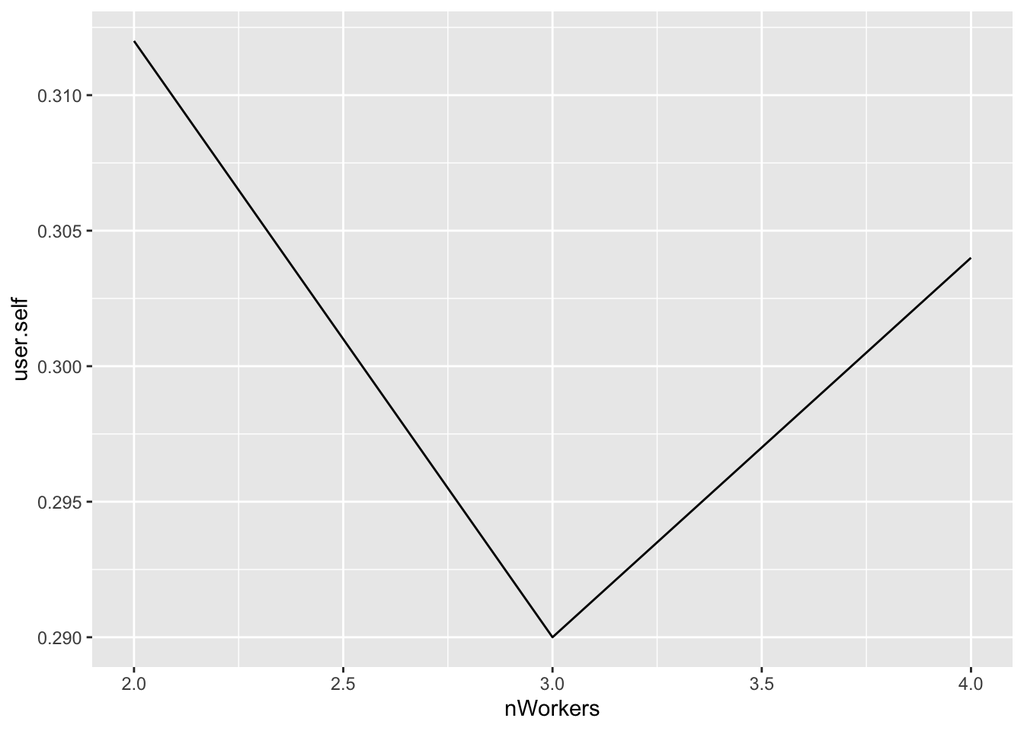

```r
d <- data.frame(nWorkers = 2:4, t(sapply(resultsParallel, function(x) x$time)))
qplot(x = nWorkers, y = user.self, geom="line", data = d)
```

We see that 3 workers did ok, but 4 workers actually increased the time (probably because of my machine only has 4 cores total).

We can check the results to find which lambda gave us the minimum CV error.

```r
lapply(resultsParallel, function(x) x$cv$lambda.min)
```

```
## [[1]]
## [1] 0.001919066
##
## [[2]]
## [1] 0.001919066
##
## [[3]]
## [1] 0.001919066
```

## Runs using `snow` with 2, 3, 4 workers

Next, we try using the `snow` workers. SNOW stands for Simple Network of Workstations and can make use of machines on network. We will, of course, use the only machine we have at our disposal!

```r
## SNOW Run
runSnow <- function(n, seed = 12345) {
    catn <- function(...) cat(..., "\n")
    internetAd <- readRDS("internetAd.RDS")

    catn("Percent non-zero per glmnet paper",
    (sum(internetAd$x > 0) + sum(internetAd$y > 0)) /
    (prod(dim(internetAd$x)) + length(internetAd$y)))

    stopifnot(require(doSNOW))
    cl <- makeCluster(n)
    registerDoSNOW(cl)
    set.seed(seed)
    time <- system.time(cv <- cv.glmnet(internetAd$x, internetAd$y,
                                        family = "binomial", type.measure = "class",
                                        parallel = TRUE))
    stopCluster(cl)
    list(time = time, cv = cv)
}
resultsSnow <- lapply(2:4, runSnow)
```

```
## Percent non-zero per glmnet paper 0.01166918
```

```
## Percent non-zero per glmnet paper 0.01166918
## Percent non-zero per glmnet paper 0.01166918
```

The same plot. The overhead can be significant enough to obliterate any gains on my simple laptop.

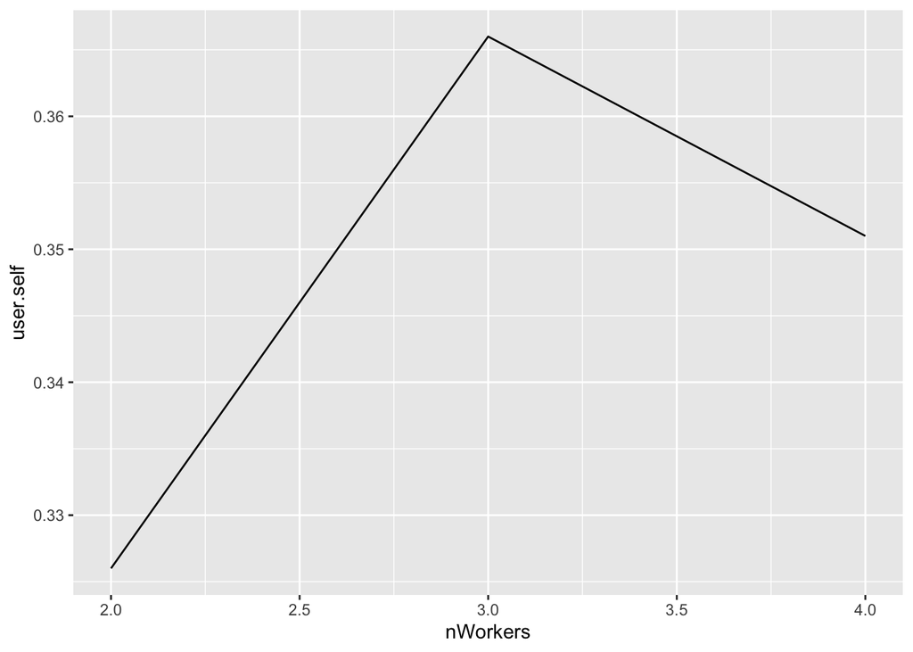

```r
d <- data.frame(nWorkers = 2:4, t(sapply(resultsSnow, function(x) x$time)))
qplot(x = nWorkers, y = user.self, geom = "line", data = d)
```

We can check the results to find which lambda gave us the minimum CV error.

```r
lapply(resultsSnow, function(x) x$cv$lambda.min)
```

```
## [[1]]
## [1] 0.001919066
##
## [[2]]
## [1] 0.001919066
##
## [[3]]
## [1] 0.001919066
```

## Cluster utilization.

For $n=3$ workers, we can a worker utilization plot for `runSnow` using `snow.time`.

```r
snowPlot <- function(n, seed = 12345) {
    catn <- function(...) cat(..., "\n")
    internetAd <- readRDS("internetAd.RDS")

    catn("Percent non-zero per glmnet paper",
    (sum(internetAd$x > 0) + sum(internetAd$y > 0)) /
    (prod(dim(internetAd$x)) + length(internetAd$y)))

    stopifnot(require(doSNOW))
    cl <- makeCluster(n)
    registerDoSNOW(cl)
    set.seed(seed)
    plot <- snow.time(cv <- cv.glmnet(internetAd$x, internetAd$y,
                                      family = "binomial", type.measure = "class",
                                      parallel = TRUE))
    stopCluster(cl)
    list(plot = plot, cv = cv)
}
snowResults <- snowPlot(n = 3)
```

```
## Percent non-zero per glmnet paper 0.01166918
```

Utilization plot for `snow`.

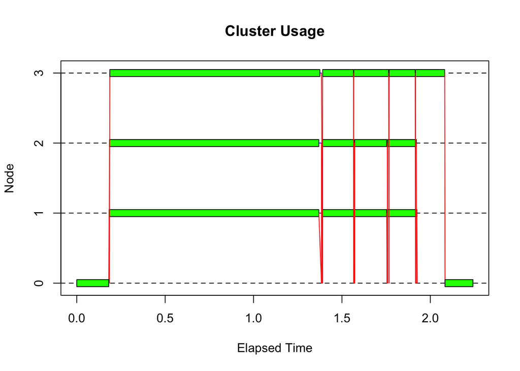

```r
plot(snowResults$plot)
```

This utilization plot shows that all the cores were reasonably utilized with minimal idle times.